# Predicting barbell lifts execution quality

Roger Basso Brusa

12 May 2017

## Summary

The purpose of this machine learning project is to predict the execution quality of barbell lifts using a provided dataset. After providing a background for the data collection, some exploratory data analysis will be executed. Then the data will be cleansed and its dimensions reduced. Cross validation will be applied and a random forest caret package method will be used to create a model to predict the target variable. In and out of sample errors will be compared and, finally, the model will be applied to a test set of 20 cases, validated through an online questionnaire.

## Background

Using devices such as Jawbone Up, Nike FuelBand, and Fitbit it is now possible to collect a large amount of data about personal activity relatively inexpensively. These type of devices are part of the quantified self movement - a group of enthusiasts who take measurements about themselves regularly to improve their health, to find patterns in their behavior, or because they are tech geeks. One thing that people regularly do is quantify how much of a particular activity they do, but they rarely quantify how well they do it. In this project, the goal will be to use data from accelerometers on the belt, forearm, arm, and dumbell of 6 participants. They were asked to perform barbell lifts correctly and incorrectly in 5 different ways. The data for the exercise can be downloaded from the website http://groupware.les.inf.puc-rio.br/har (Weight Lifting Exercise Dataset), where extra information can be found.

## Exploratory data analysis

The data is loaded with the stringsAsFactors parameter set to false to prevent R from converting some numeric field into factors.

```r
training <- read.csv('pml-training.csv', header = T, stringsAsFactors = F)
testing <- read.csv('pml-testing.csv', header = T, stringsAsFactors = F)
```

The training dataset is quite large, consisting of almost 20 thousand observations of 160 variables. The testing dataset contains 20 observations and will be used to test the model using the online questionnaire. The high number of columns will require the adoption of a dimension reduction strategy in order to improve the training performance.

```r
dim(training)
```

```
[1] 19622   160
```

```r
dim(testing)
```

```
[1]  20 160
```

The structure of the training data seems to reveal that not all the fields carry useful information for the purpose of the prediction.

```r
str(training)
```

```
'data.frame':   19622 obs. of  160 variables:
 $ X                       : int  1 2 3 4 5 6 7 8 9 10 ...
 $ user_name               : chr  "carlitos" "carlitos" "carlitos" "carlitos" ...
 $ raw_timestamp_part_1    : int  1323084231 1323084231 1323084231 1323084232 1323084232 1323084232 1323084232 1323084232 1323084232 1323084232 ...
 $ raw_timestamp_part_2    : int  788290 808298 820366 120339 196328 304277 368296 440390 484323 484434 ...
 $ cvtd_timestamp          : chr  "05/12/2011 11:23" "05/12/2011 11:23" "05/12/2011 11:23" "05/12/2011 11:23" ...
 $ new_window              : chr  "no" "no" "no" "no" ...
 $ num_window              : int  11 11 11 12 12 12 12 12 12 12 ...
 $ roll_belt               : num  1.41 1.41 1.42 1.48 1.48 1.45 1.42 1.42 1.43 1.45 ...
 $ pitch_belt              : num  8.07 8.07 8.07 8.05 8.07 8.06 8.09 8.13 8.16 8.17 ...
 $ yaw_belt                : num  -94.4 -94.4 -94.4 -94.4 -94.4 -94.4 -94.4 -94.4 -94.4 -94.4 ...
 $ total_accel_belt        : int  3 3 3 3 3 3 3 3 3 3 ...
 $ kurtosis_roll_belt      : chr  "" "" "" "" ...
 $ kurtosis_picth_belt     : chr  "" "" "" "" ...
 $ kurtosis_yaw_belt       : chr  "" "" "" "" ...
```

[output cut: 86 more lines]

This assumption is confirmed by the following barplot, where for each column on the X axis the number of non NA or empty values has been reported on the Y axis. In particular, the X field is just a counter, some date time stamp fields can be ignored, some columns contain a majority of empty or NA values. These columns will be safely removed in the next stage.

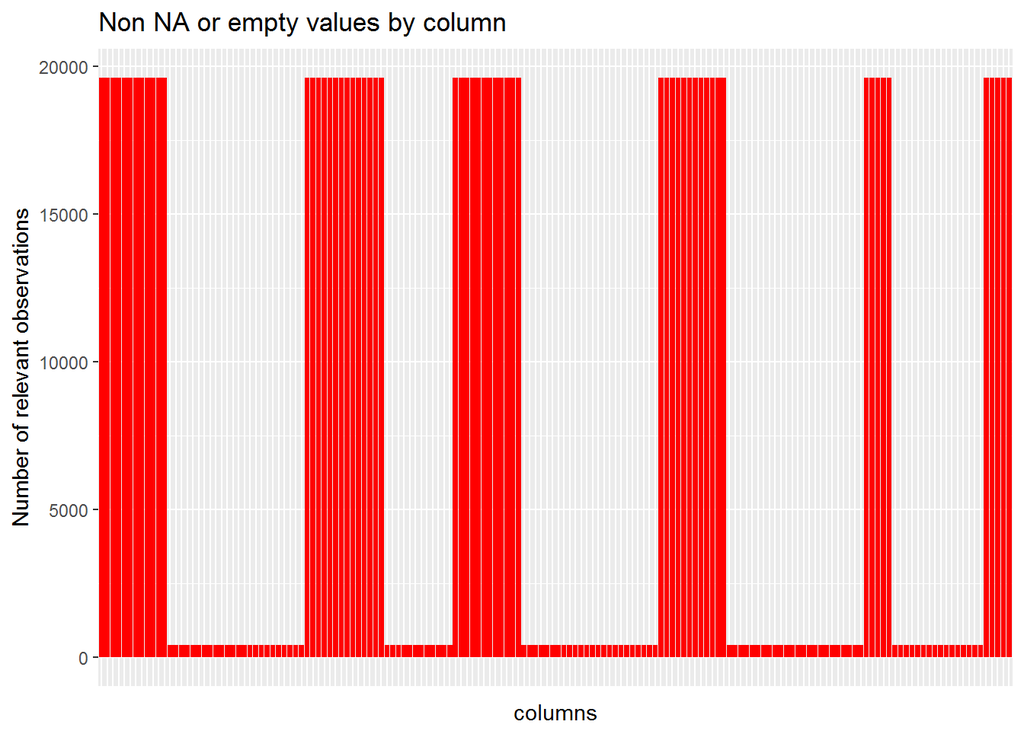

```r
dataG2 <- apply(training, 2, function(x) length(which(!is.na(x) & !(x == ""))))
dataG2b <- data.frame(names = names(training), count = dataG2)
g2 <- ggplot(dataG2b, aes(x = dataG2b$names, y = dataG2b$count))
g2 <- g2 + geom_bar(stat = "identity", fill = "red")
g2 <- g2 + theme(axis.text.x = element_blank(), axis.ticks.x = element_blank())
g2 <- g2 + xlab("columns")
g2 <- g2 + ylab("Number of relevant observations")
g2 <- g2 + ggtitle("Non NA or empty values by column")
g2
```

The 2 datasets (training and testing) have the same number of columns, but their last field is different, as it can be seen below. This will need to be taken into account during the next stages.

```r
tail(names(training))
```

```
[1] "accel_forearm_y"  "accel_forearm_z"  "magnet_forearm_x"
[4] "magnet_forearm_y" "magnet_forearm_z" "classe"
```

```r
tail(names(testing))
```

```
[1] "accel_forearm_y"  "accel_forearm_z"  "magnet_forearm_x"
[4] "magnet_forearm_y" "magnet_forearm_z" "problem_id"
```

The purpose of this project is to train a model to predict the ‘classe’ variable, where classe A corresponds to the barbell lifts correctly executed and the other classes otherwise. The bar plot below shows the distribution of the ‘classe’ variable in the training dataset.

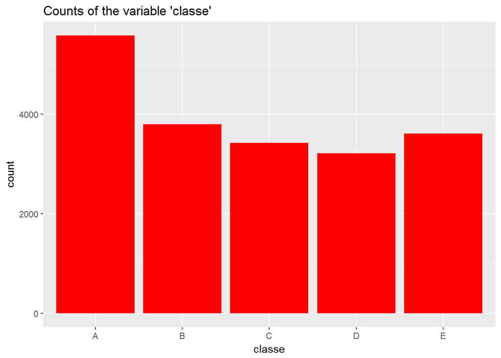

```r
g1 <- ggplot(training, aes(x = training$classe))
g1 <- g1 + geom_bar(fill = "red")
g1 <- g1 + xlab("classe")
g1 <- g1 + ggtitle("Counts of the variable 'classe'")
g1
```

## Data cleansing

In order to apply the same transformations to both the training and testing datasets, the 2 datasets will be merged together and the transformations will be applied to the merged dataset. Then, before training a model, the 2 datasets will be separated. Firstly, the 2 datasets must have the same data structure (columns), then they are merged together.

```r
testing$classe <- NA
training$problem_id <- NA
training <- rbind(training, testing)
dim(training)
```

```
[1] 19642   161
```

Now the training dataset contains 19642 observations. At this point all the redundant columns can be removed, leaving only the most meaningful variables. Now the training dataset has 53 features and a label.

```r
training <- training[, !apply (is.na(training[1,]), 2, all)]
training <- training[ , -which(names(training) %in% c("X","user_name", "raw_timestamp_part_1", "raw_timestamp_part_2", "cvtd_timestamp"))]
training <- training[ , -which(names(training) %in% c("kurtosis_yaw_belt","skewness_yaw_belt", "kurtosis_yaw_dumbbell", "skewness_yaw_dumbbell", "kurtosis_yaw_forearm", "skewness_yaw_forearm", "amplitude_yaw_forearm", "amplitude_yaw_dumbbell", "amplitude_yaw_belt"))]
training <- training[ , -which(names(training) %in% c("new_window"))]
training <- training[ , -which(names(training) %in% c("kurtosis_roll_belt", "kurtosis_picth_belt", "skewness_roll_belt", "skewness_roll_belt.1", "kurtosis_roll_arm", "kurtosis_picth_arm", "kurtosis_yaw_arm", "skewness_roll_arm", "skewness_pitch_arm", "skewness_yaw_arm", "kurtosis_roll_dumbbell", "kurtosis_picth_dumbbell", "skewness_roll_dumbbell", "skewness_pitch_dumbbell", "max_yaw_dumbbell", "min_yaw_dumbbell", "kurtosis_roll_forearm", "kurtosis_picth_forearm", "skewness_roll_forearm", "skewness_pitch_forearm", "max_yaw_forearm", "min_yaw_forearm"))]
training <- training[ , -which(names(training) %in% c("max_yaw_belt", "min_yaw_belt"))]
str(training)
```

```
'data.frame':   19642 obs. of  54 variables:
 $ num_window          : int  11 11 11 12 12 12 12 12 12 12 ...
 $ roll_belt           : num  1.41 1.41 1.42 1.48 1.48 1.45 1.42 1.42 1.43 1.45 ...
 $ pitch_belt          : num  8.07 8.07 8.07 8.05 8.07 8.06 8.09 8.13 8.16 8.17 ...
 $ yaw_belt            : num  -94.4 -94.4 -94.4 -94.4 -94.4 -94.4 -94.4 -94.4 -94.4 -94.4 ...
 $ total_accel_belt    : int  3 3 3 3 3 3 3 3 3 3 ...
 $ gyros_belt_x        : num  0 0.02 0 0.02 0.02 0.02 0.02 0.02 0.02 0.03 ...
 $ gyros_belt_y        : num  0 0 0 0 0.02 0 0 0 0 0 ...
 $ gyros_belt_z        : num  -0.02 -0.02 -0.02 -0.03 -0.02 -0.02 -0.02 -0.02 -0.02 0 ...
 $ accel_belt_x        : int  -21 -22 -20 -22 -21 -21 -22 -22 -20 -21 ...
 $ accel_belt_y        : int  4 4 5 3 2 4 3 4 2 4 ...
 $ accel_belt_z        : int  22 22 23 21 24 21 21 21 24 22 ...
 $ magnet_belt_x       : int  -3 -7 -2 -6 -6 0 -4 -2 1 -3 ...
 $ magnet_belt_y       : int  599 608 600 604 600 603 599 603 602 609 ...
 $ magnet_belt_z       : int  -313 -311 -305 -310 -302 -312 -311 -313 -312 -308 ...
```

[output cut: 40 more lines]

## Dimension reduction

To achieve a further reduction on the number of features, a principal component analysis method is applied to the training data. The PCA created 26 features to maintain 95% of the variability of the original data. Now the data is a 19642 x 27 dataset.

```r
preproc <- preProcess(training[,-54], method = "pca")
trainingPC <- predict(preproc, training[,-54])
trainingPC <- cbind(classe = training$classe, trainingPC)
preproc
```

```
Created from 19642 samples and 53 variables

Pre-processing:
  - centered (53)
  - ignored (0)
  - principal component signal extraction (53)
  - scaled (53)

PCA needed 26 components to capture 95 percent of the variance
```

```r
dim(trainingPC)
```

```
[1] 19642    27
```

Let’s not forget that the last 20 rows of the training dataset are the original testing dataset. Now those 20 rows are split from the main training data.

```r
testingPC <- trainingPC[19623:19642,]
trainingPC <- trainingPC[1:19622,]
```

## Cross validation

There are multiple cross validation options available. In this case it has been decided to split the main training data into 2 datasets: 90% of the original data will become the final training data and the remaining 10% will be used to test the resulting model.

```r
inTrain <- createDataPartition(y = trainingPC$classe, p = 0.9, list = FALSE)
training0 <- trainingPC[inTrain,]
testing0 <- trainingPC[-inTrain,]
dim(training0)
```

```
[1] 17662    27
```

```r
dim(testing0)
```

```
[1] 1960   27
```

```r
##training0 <- trainingPC[ sample(1:nrow(trainingPC), size=500, replace=FALSE), ]
##testing0 <- trainingPC[ sample(1:nrow(trainingPC), size=50, replace=FALSE), ]
```

## Training a model

The first model to be tested is a Random Forest. It turns out that the accuracy achieved with this model is good enough that it has been decided it is not necessary either trying other models or reiterating the training on other splits of the data.

```r
fit0 <- train(classe ~ ., data = training0, method = "rf")
fit0
```

```
Random Forest

17662 samples
   26 predictor
    5 classes: 'A', 'B', 'C', 'D', 'E'

No pre-processing
Resampling: Bootstrapped (25 reps)
Summary of sample sizes: 17662, 17662, 17662, 17662, 17662, 17662, ...
Resampling results across tuning parameters:

  mtry  Accuracy   Kappa
   2    0.9736369  0.9666490
  14    0.9685898  0.9602634
  26    0.9605794  0.9501291

Accuracy was used to select the optimal model using  the largest value.
The final value used for the model was mtry = 2.
```

## In sample error vs out of sample error

The ‘in sample error’ can be calculated using a portion of the training data to test the accuracy of the model. The accuracy of the model in this case is expected to be high, as the test data is part of the train data (it is in fact 100%).

```r
testingIN <- training0[ sample(1:nrow(training0), size=50, replace=FALSE), ]
resultIN <- predict(fit0, newdata = testingIN)
resultIN <- as.data.frame(resultIN)
resultIN$classe <- testingIN$classe
confusionMatrix(resultIN$resultIN, resultIN$classe)
```

```
Confusion Matrix and Statistics

          Reference
Prediction  A  B  C  D  E
         A 14  0  0  0  0
         B  0  8  0  0  0
         C  0  0 13  0  0
         D  0  0  0  6  0
         E  0  0  0  0  9

Overall Statistics

               Accuracy : 1
                 95% CI : (0.9289, 1)
    No Information Rate : 0.28
    P-Value [Acc > NIR] : < 2.2e-16

                  Kappa : 1
 Mcnemar's Test P-Value : NA

Statistics by Class:

                     Class: A Class: B Class: C Class: D Class: E
Sensitivity              1.00     1.00     1.00     1.00     1.00
Specificity              1.00     1.00     1.00     1.00     1.00
Pos Pred Value           1.00     1.00     1.00     1.00     1.00
Neg Pred Value           1.00     1.00     1.00     1.00     1.00
Prevalence               0.28     0.16     0.26     0.12     0.18
Detection Rate           0.28     0.16     0.26     0.12     0.18
Detection Prevalence     0.28     0.16     0.26     0.12     0.18
Balanced Accuracy        1.00     1.00     1.00     1.00     1.00
```

The ‘out of sample error’ instead is calculated using the testing dataset that was created at cross validation stage. The accuracy is expected to be lower than that seen in the ‘in sample error’ case, but it is still very high (almost 100%).

```r
result0 <- predict(fit0, newdata = testing0)
result0 <- as.data.frame(result0)
result0$classe <- testing0$classe
confusionMatrix(result0$result0, result0$classe)
```

```
Confusion Matrix and Statistics

          Reference
Prediction   A   B   C   D   E
         A 558   0   0   0   0
         B   0 379   0   0   0
         C   0   0 342   4   0
         D   0   0   0 317   1
         E   0   0   0   0 359

Overall Statistics

               Accuracy : 0.9974
                 95% CI : (0.9941, 0.9992)
    No Information Rate : 0.2847
    P-Value [Acc > NIR] : < 2.2e-16

                  Kappa : 0.9968
 Mcnemar's Test P-Value : NA

Statistics by Class:

                     Class: A Class: B Class: C Class: D Class: E
Sensitivity            1.0000   1.0000   1.0000   0.9875   0.9972
Specificity            1.0000   1.0000   0.9975   0.9994   1.0000
Pos Pred Value         1.0000   1.0000   0.9884   0.9969   1.0000
Neg Pred Value         1.0000   1.0000   1.0000   0.9976   0.9994
Prevalence             0.2847   0.1934   0.1745   0.1638   0.1837
Detection Rate         0.2847   0.1934   0.1745   0.1617   0.1832
Detection Prevalence   0.2847   0.1934   0.1765   0.1622   0.1832
Balanced Accuracy      1.0000   1.0000   0.9988   0.9935   0.9986
```

Finally the model is applied to the original testing data. The results of this operation have been tested answering the questionnaire online with outcome in line with the above accuracy.

```r
result1 <- predict(fit0, newdata = testingPC)
result1 <- as.data.frame(result1)
print(result1)
```

```
   result1
1        B
2        A
3        A
4        A
5        A
6        E
7        D
8        B
9        A
10       A
11       B
12       C
13       B
14       A
15       E
16       E
17       A
18       B
19       B
20       B
```